# Code-Red_module6

Liz Asprinio, Tingwei Hu, James Kim, Justin Lau

2022-11-02

# Introduction

The Lepidoptera are an order of insects compromised of nearly 160,000 species of butterflies and moths.They have both forewings and hindwings, each playing roles in functions such as flying and attracting mates. Previous studies have found that if the hindwings of a moth or butterfly are removed, the insect can fly but its ability for linear and turning acceleration is greatly hindered (Jantzen and Eisner 2008). Based on these findings, it can be concluded that Lepidoptera hindwing shape is due to selection for improved flight maneuverability. Further studies suggest that selection for forewing shape is determined by flight ability, while selection for hindwing shape is determined by several possibilities, such as neutral selection, sexual selection, and predator avoidance (Sourakov 2013, Barber et al. 2015, Willmott et al. 2017, Rubin et al. 2018, Chazot et al. 2016). While these studies show that Lepidoptera forewings and hindwings have evolved different functions, there is still much that is not known about their evolutionary history. The purpose of this study is to determine whether Lepidoptera forewings and hindwings vary in their evolutionary rates, if different lineages have evolved at significantly different rates, and if forewing and hindwing shapes are correlated. This will be done by running a comparative phylogenetic analysis on the wing shape data of more than 200 species of Lepidoptera, using the phylogeny provided by Kawahara et al. (2019).

Great intro!

# Methods

Images of various species of Lepidoptera were digitized using FIJI. Because the initial outlines included both forewing and hindwing outlines for each species, these were separated using file names. Next, a Procrustes transformation was performed in order to translate, rotate, and scale the outlines for better analysis of their shape without factoring in arbitrary wing size. Elliptical Fourier Analysis (EFA) was performed in order to describe wing shapes. Principle Component Analysis (PCA) was then performed in order to minimize the number of variables explaining the variance in the data set. The functions for these analyses are included in the R package “Momocs.” PCA data was visualized to determine the distribution of morphoshape of the wings of the different species as well as the amount of variance described by different variables. To prepare the comparative analysis on the PCA data, the phylogenetic tree was loaded positioned upper left. The file names of each species were also identified using the identifier data provided by Prof. Kenaley. The PC data was added to the identified species data accordingly. The phylogeny tree was modified to only include the species that were identified and had a PCA data. From here, the forewing and hindwing PC1 and PC2 were separated in different variable under the Brownian Motion. To determine the evolutionary rate, “RRphylo” package was used to determine the rate of evolution based on wing shape and from there, any statistically significant shift in shape evolution based on the Lepdioptera’s clades were identified. The rate of the significant evolutionary shift was identified along with the name of clades. The phylogenetic independent contrast was performed on the PC datas to separate the original tip data independent of each other. The PC values of forewing and hindwing data were then compared via linear model and analyzed to see if statistically significant value existed.

# Results

## Shape Analysis

After visualizing the forewing and hindwing datas of the Lepidoptera species, the two wings were separated and scaled so that the wings were adjusted for their difference in size. This allowed for the contrast of wing shape only.

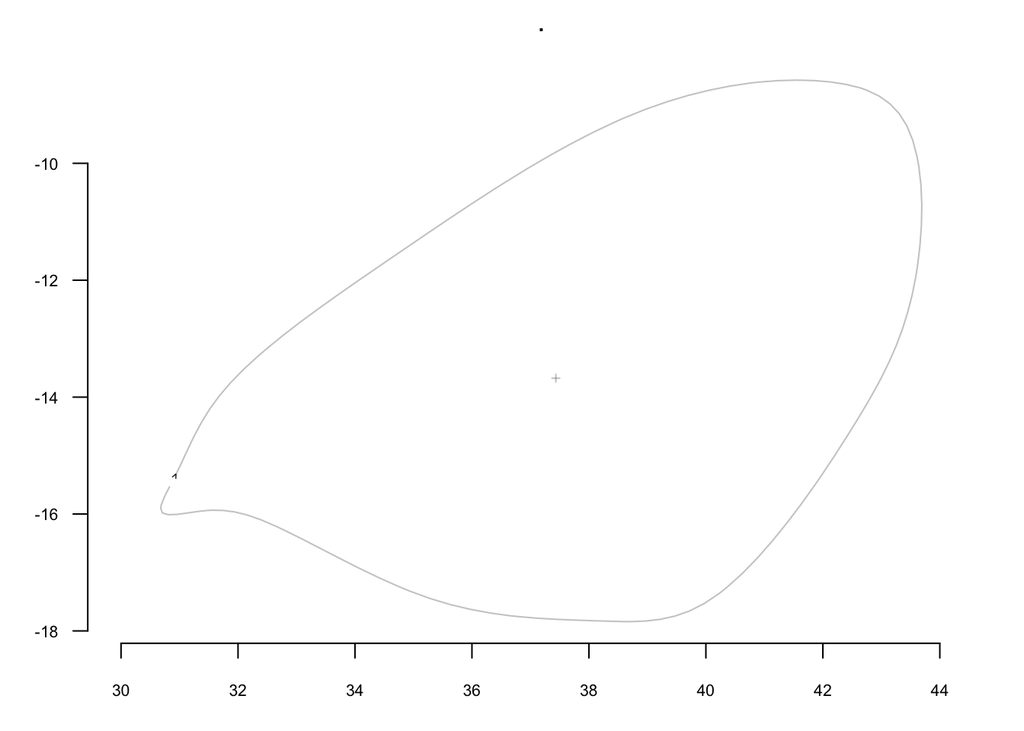

```
## no landmarks defined in $ldk, so trying to work on $coo directly
```

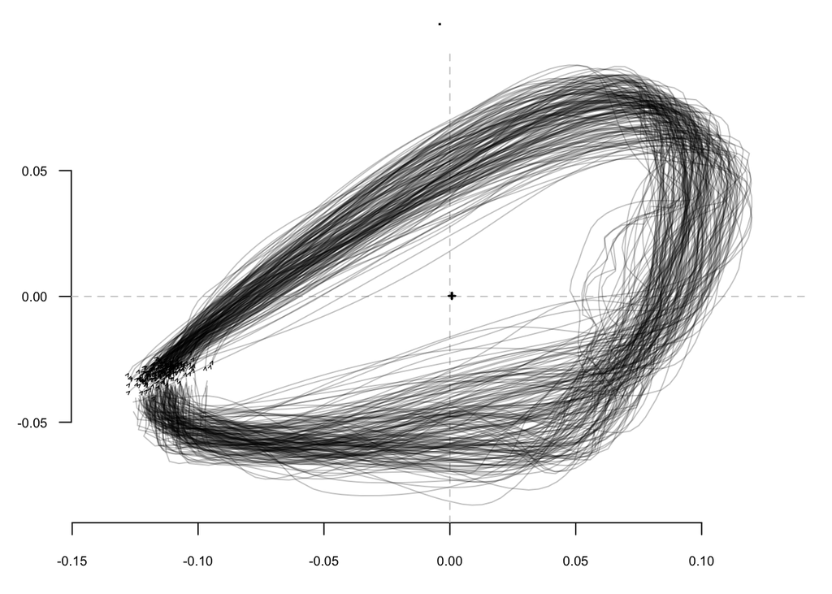

*Figure 2. Visualization of Forewings using EFA after the size of the wings have been equalized*

```r
hind.min <- hindwings %>%
  coo_nb() %>%
  min()
hindwings %>%
   coo_interpolate(hind.min) %>%
  coo_slide(id=1) %>%
   coo_align()  %>%
   fgProcrustes() %>%
  stack()
```

```
## no landmarks defined in $ldk, so trying to work on $coo directly
```

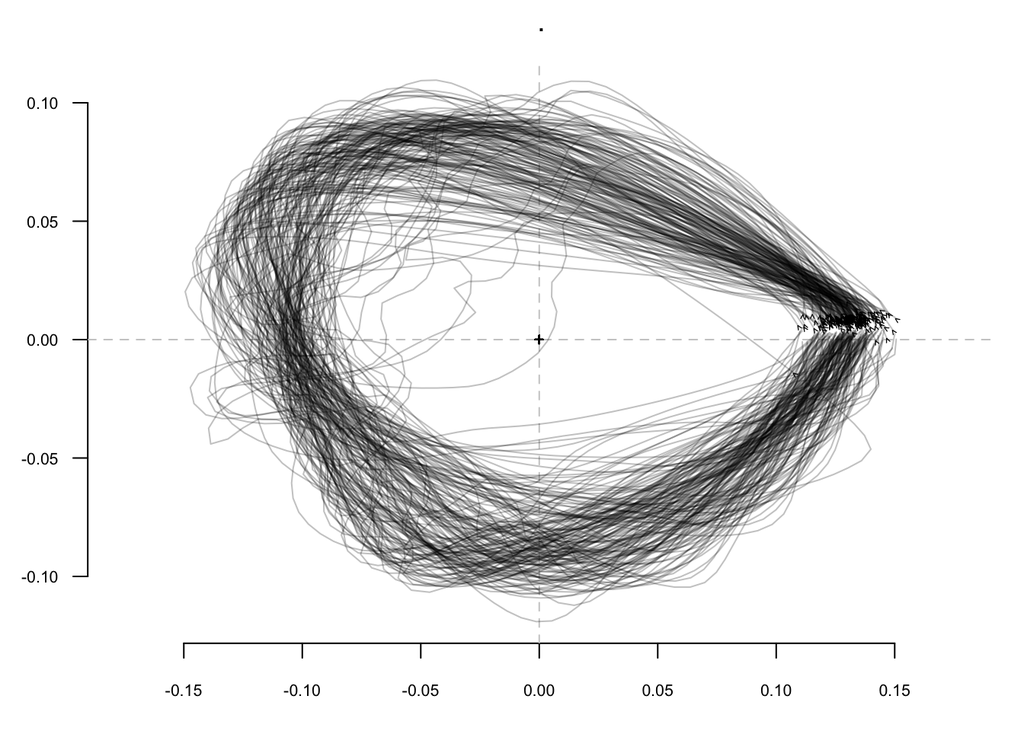

*Figure 3. Visualization of Hindwings using EFA after the size of the wings have been equalized*

The visualized forewings and hindwings were then processed through PCA independently from each other. This allowed us to see the distribution of wing shapes for the forewing and the hindwing.

```
## no landmarks defined in $ldk, so trying to work on $coo directly
```

```
## 'nb.h' set to 7 (99% harmonic power)
```

```
## no landmarks defined in $ldk, so trying to work on $coo directly
```

```
## 'nb.h' set to 8 (99% harmonic power)
```

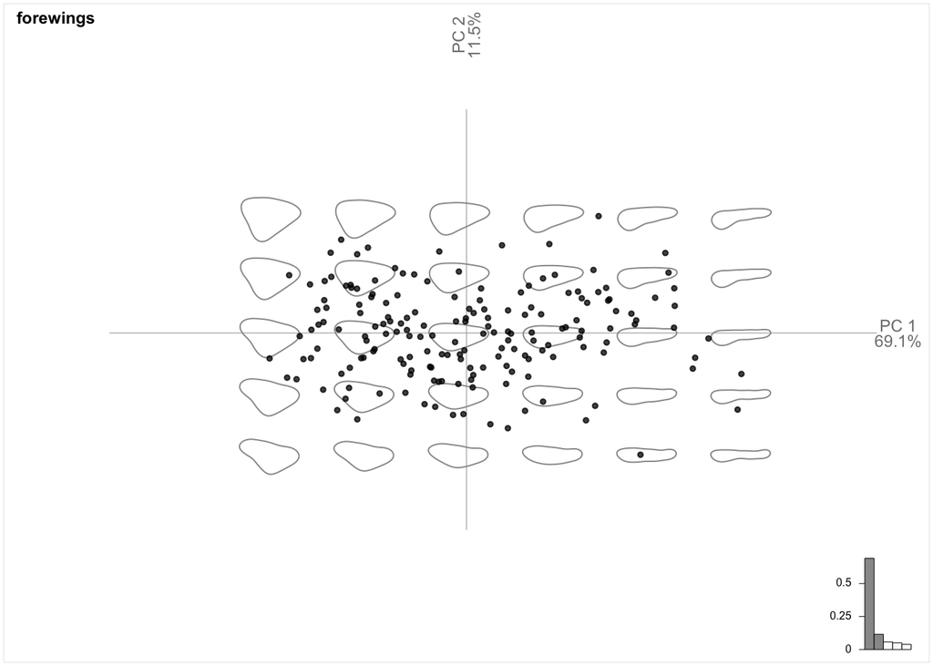

*Figure 4. PCA analysis of Forewings*

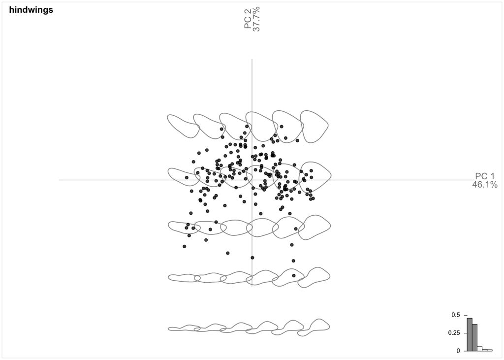

*Figure 5. PCA analysis of Hindwings*

## Comparative Analysis

After acquiring the PCA data, the phylogenetic tree of Lepidoptera was filtered to only include the species that were included in this study.

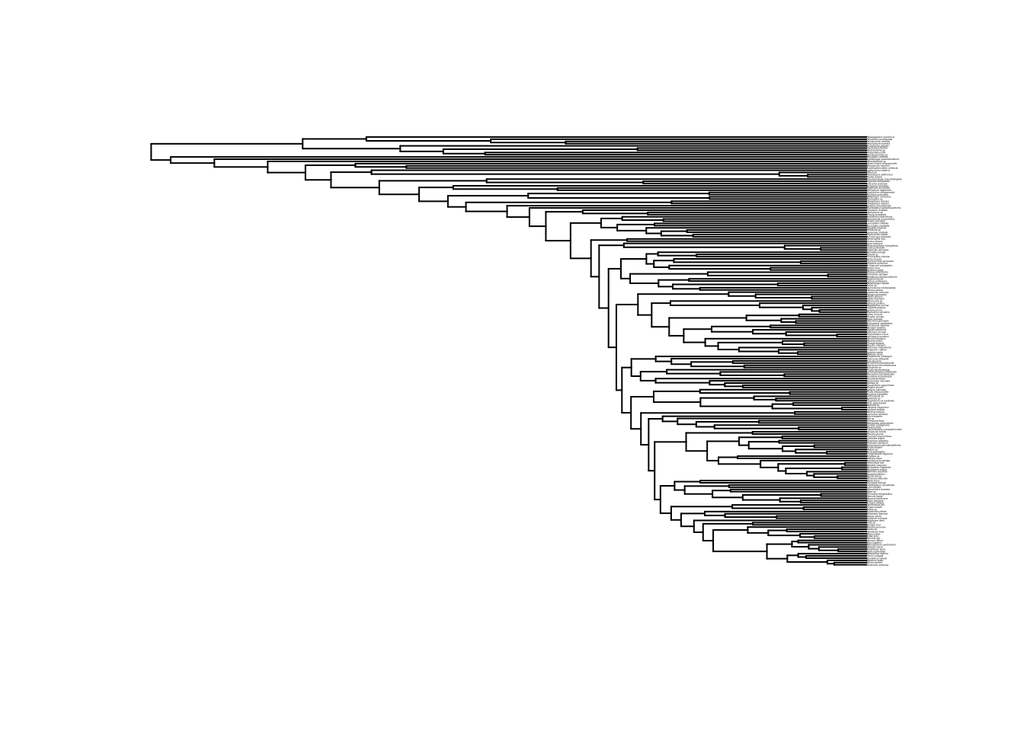

```r
lep.tree <- ape::read.tree("lep_tree2.tre")

plot(lep.tree,cex=0.1)
```

*Figure 6. Phylogenetic Tree of Lepidoptera*

## Evolutionary Rates

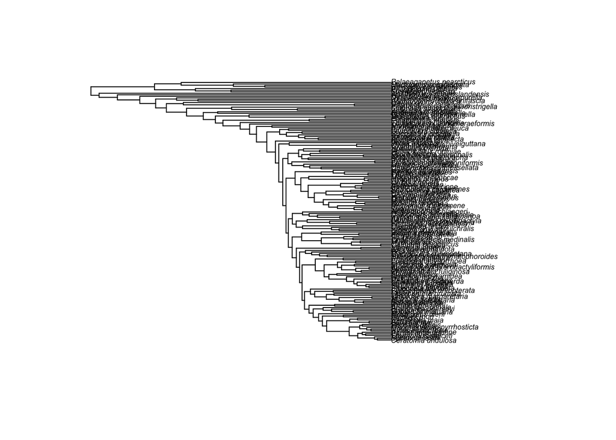

*Figure 7. Adjusted phylogenetic tree of Lepidoptera included in the study*

```
## [1] 0.006535527
```

```
## [1] 0.01014157
```

```
## [1] 0.002411568
```

```
## [1] 0.01870921
```

## Shifts in Evolutionary Rates

The evolutionary shift was then measured to determine if any significant shift in evolutionary rate was present according to the different clades of Lepidoptera under the Brownian model.

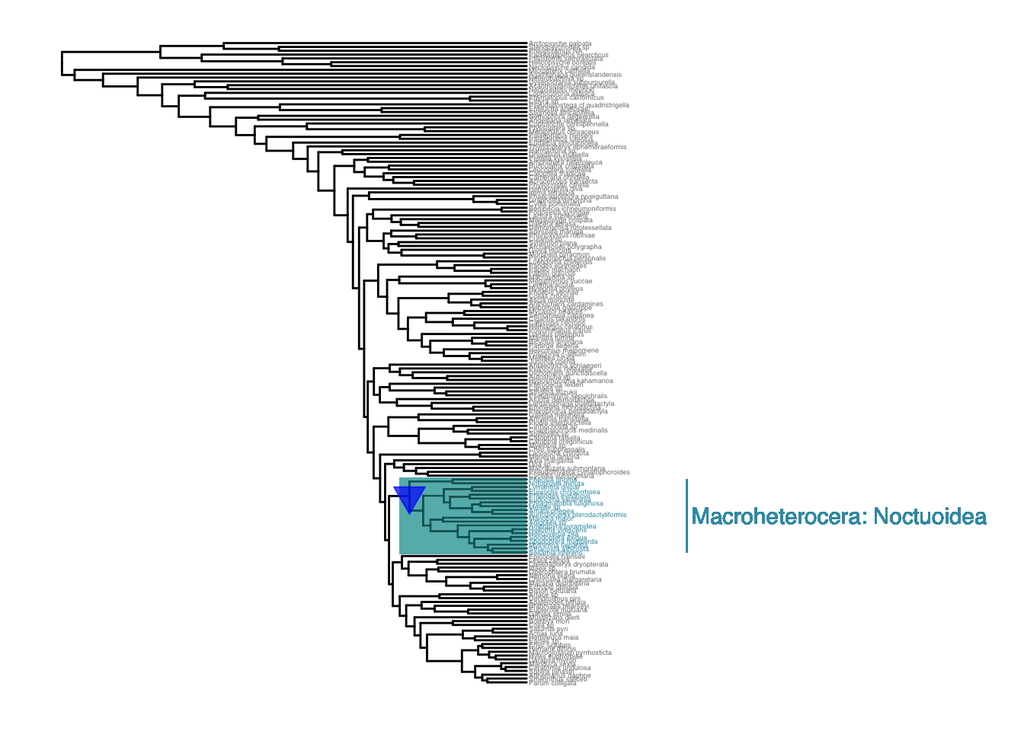

```r
tax.names <- readRDS("Lep_classification.RDS")

hindPC1.res <- plot_SS(lep.tree2,hindPC1.SS,tax = tax.names)
forePC1.res <- plot_SS(lep.tree2,forePC1.SS,tax = tax.names)
hindPC1.res$plot
```

```r
hindPC1.res$res
```

```
## # A tibble: 1 × 4
##       n rate.difference p.value clade
##   <dbl>           <dbl>   <dbl> <chr>
## 1   225        -0.00194   0.001 Macroheterocera: Noctuoidea
```

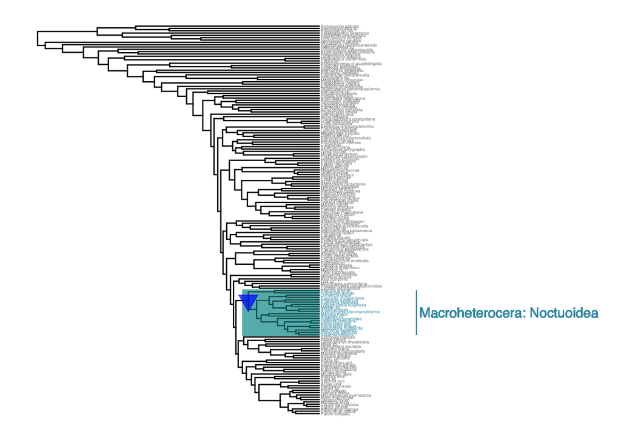

```r
forePC1.res$plot
```

```r
forePC1.res$res
```

```
## # A tibble: 1 × 4
##       n rate.difference p.value clade
##   <dbl>           <dbl>   <dbl> <chr>
## 1   225        -0.00162   0.001 Macroheterocera: Noctuoidea
```

*Figure 8. Significant evolutionary rate found in the Lepidoptera phylogeny*

## Shape Evolution Correlation

The PC1 and PC2 data that was underwent phylogenetic independent contrast showed that the PC1 data of forewing and hindwing shape comparison had much more significant correlation compared to the PC2.

### PC1

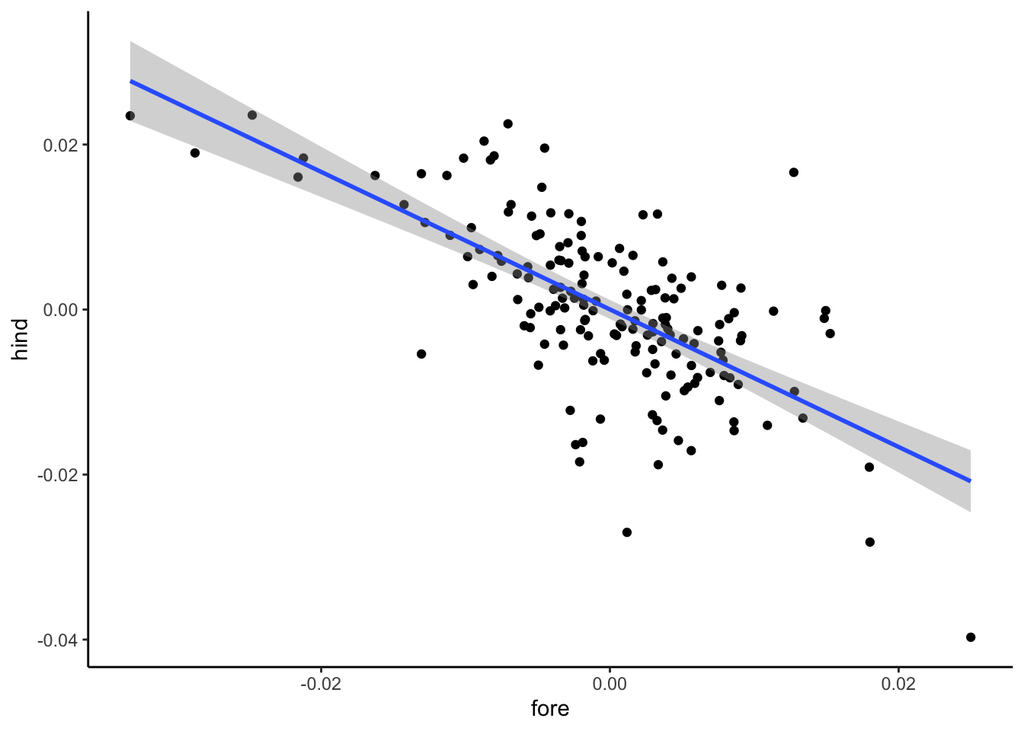

```
##
## Call:
## lm(formula = hind ~ fore, data = PC1.pic)
##
## Residuals:
##        Min         1Q     Median         3Q        Max
## -0.0260329 -0.0040299 -0.0001764  0.0048320  0.0272273
##
## Coefficients:
##               Estimate Std. Error t value Pr(>|t|)
## (Intercept)  1.629e-05  5.845e-04   0.028    0.978
## fore        -8.335e-01  7.209e-02 -11.562   <2e-16 ***
## ---
## Signif. codes:  0 '***' 0.001 '**' 0.01 '*' 0.05 '.' 0.1 ' ' 1
##
## Residual standard error: 0.007552 on 165 degrees of freedom
## Multiple R-squared:  0.4476, Adjusted R-squared:  0.4442
## F-statistic: 133.7 on 1 and 165 DF,  p-value: < 2.2e-16
```

*Figure 9. Phylogenetic Independent Contrast of PC1*

### PC2

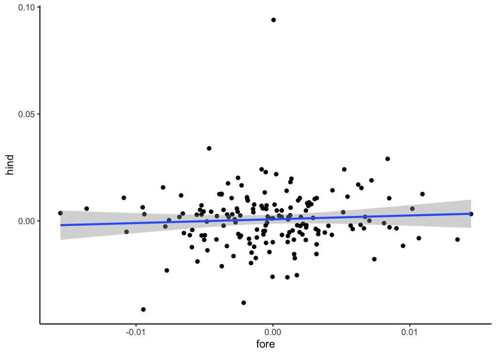

```
##
## Call:
## lm(formula = hind ~ fore, data = PC2.pic)
##
## Residuals:
##       Min        1Q    Median        3Q       Max
## -0.040493 -0.007104  0.000357  0.006907  0.093219
##
## Coefficients:
##              Estimate Std. Error t value Pr(>|t|)
## (Intercept) 0.0007655  0.0010652   0.719    0.473
## fore        0.1778140  0.2162627   0.822    0.412
##
## Residual standard error: 0.01375 on 165 degrees of freedom
## Multiple R-squared:  0.00408,    Adjusted R-squared:  -0.001955
## F-statistic: 0.676 on 1 and 165 DF,  p-value: 0.4121
```

*Figure 10. Phylogenetic Independent Contrast of PC2*

Great work implementing all the code, but your results section reads like a methods section, ie. there’s no narrative reporting the results.

```r
grade <- 75
grade <- grade-3
```

# Discussion

This is a nice summary of the results, but it lacks a connection to what’s at stake biologically. Why would it be that some groups hade lower rates? What’s behind the hindwing evoloving faster than the forewing, etc?

```r
grade <- grade-2
```

# Author Contributions

Tingwei - Discussion, Rmd Setup, preprocessing up to EFA, PCA revision, PIC for PC2

Justin - Wing Tracing, PCA Analysis, Results, Discussion, Formatting

Liz - Introduction, Methods, Discussion, References

James - Introduction, Methods, Results, Formatting

Excellent work! Your missing some narrative to the results and the discussion could have included more context for you findings. But, your implementation of the analysis is more reflective of graduate-level work. Congrats to you all!!!

```r
print(grade)
```

```
## [1] 70
```

# References

Jantzen, Benjamin, and Thomas Eisner. 2008. “Hindwings Are Unnecessary for Flight but Essential for Execution of Normal Evasive Flight in Lepidoptera.” *Proceedings of the National Academy of Sciences* 105 (43): 16636–40.

Kawahara, Akito Y, David Plotkin, Marianne Espeland, Karen Meusemann, Emmanuel FA Toussaint, Alexander Donath, France Gimnich, et al. 2019. “Phylogenomics Reveals the Evolutionary Timing and Pattern of Butterflies and Moths.” *Proceedings of the National Academy of Sciences* 116 (45): 22657–63.

Le Roy, Camille, Vincent Debat, and Violaine Llaurens. 2019. “Adaptive Evolution of Butterfly Wing Shape: From Morphology to Behaviour.” *Biological Reviews* 94 (4): 1261–81.